# Jornada de introducción a la Genómica y la Bioinformática

Machine learning y bioinformática: análisis de componentes principales

Profesor: Carlos Pérez-Glez (departamento de Matemáticas, Estadística e Investigación Operativa)

Junio, 2019

[interactive chart not shown]

# Introducción: dimensionalidad de los datos

- En cualquier conjunto de datos bidimensional (matriz,dataset) las filas representan las observaciones o muestras (samples) y las columnas las variables (features).
- Supongamos que un conjunto de datos tiene $n$ observaciones y $p$ variables, es decir, una tabla $n \times p$.
- Ejemplo clásico: Dataset de $n=150$ muestras de flores de la especie *Iris*, sobe la que se miden $p=4$ características.

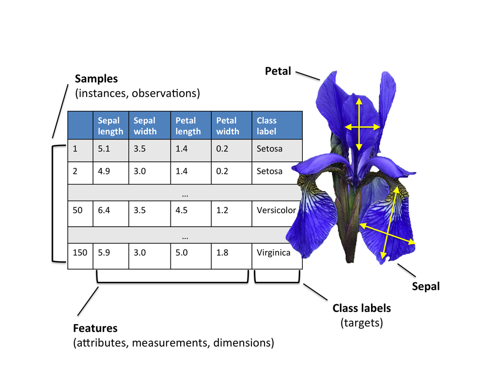

- De esta forma, se dice que los conjuntos de datos tienen un espacio muestral de dimensión $n$ (sample space) y un espacio de variables con dimensión $p$ (feature space). En general, los datasets pueden tener una o ambas dimensiones muy altas ($n$, $p$ grandes). En este caso, puede ser necesario aplicar un tipo de técnicas de aprendizaje no supervisado (unsupervised maching learning) conocida como **técnicas de reducción de la dimensionalidad** con el fin de interpretar mejor los datos.
- Observar que, a veces, las variables también se llaman *dimensiones* ya que resulta mucho más común aplicar las tecnicas de reducción de dimensionalidad a las variables.

# PCA y reducción de la dimensionalidad

- La técnica de reducción de la dimensionalidad más ampliamente conocida es el análisis de componentes principales (**principal components analysis, PCA**).
- El objetivo de esta técnica consiste en reducir las dimensiones de un dataset $p$-dimensional $X$ mediante una proyección en un subespacio $k$-dimensional, donde $k<p$.

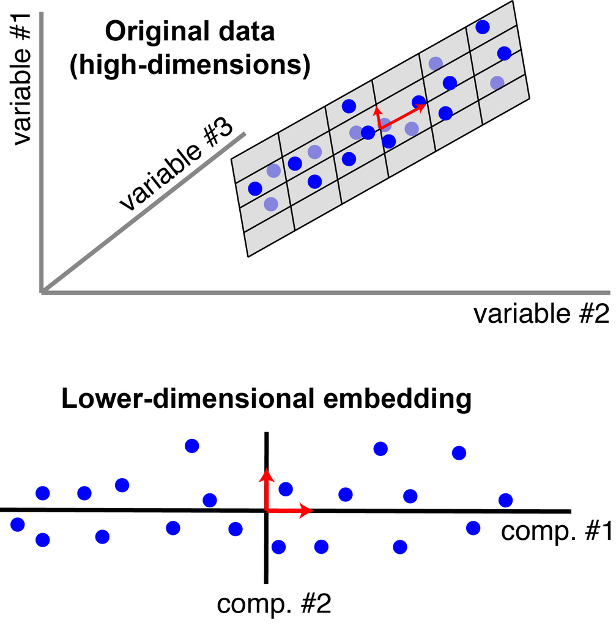

- Es decir, se reduce el espacio de $p$ variables originales a $k$ variables transformadas que reciben el nombre de **componentes**. El objetivo de la técnica consiste en resumir la mayor parte de la información de las variables originales (varianza estadística) a través de las nuevas componentes.
- El esquema anterior muestra cada punto representando una observación (fila de $X$), sobre la que observamos $p=3$ variables.
- La técnica PCA reduce la dimensionalidad de $X$ a $k=2$ componentes, que está representada por 2 vectores ortogonales (en color rojo) que definen el plano de color gris. Dicho plano recoge la máxima varianza posible del conjunto original de variables.

# PCA y reducción de la dimensionalidad

- Supongamos que tenemos un conjunto de observaciones en las que se han medido $p=2$ variables. Si representamos en un diagrama de dispersión

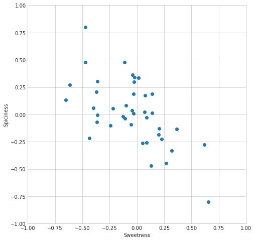

# PCA y reducción de la dimensionalidad

- Aplicar una técnica PCA para pasar de $p=2$ a $k=1$ variable supone hacer una proyección de los puntos sobre una recta:

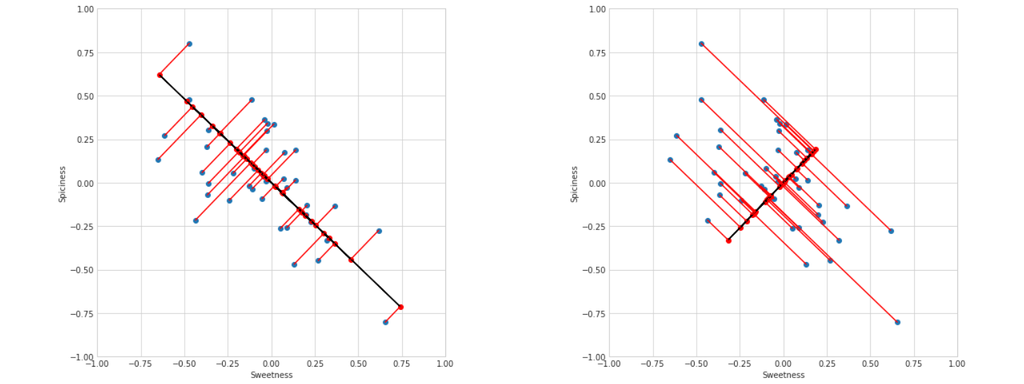

- A la **izquierda** vemos que la proyección se caracteriza por:
  - la mayor dispersión de los puntos entre sí (la dispersión representa la varianza de las observaciones).
  - la distancia cuadrática acumulada de los puntos a sus proyecciones se minimiza (dicha distancia es el error entre los puntos originales y sus proyecciones, las líneas rojas). Por esta razón, esta recta representa lo que se conoce como primera componente principal.

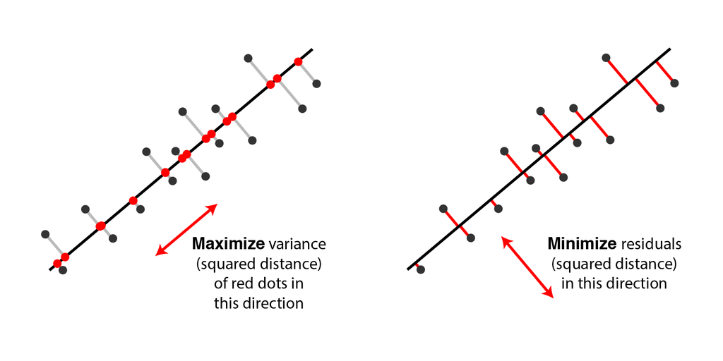

# PCA y reducción de la dimensionalidad

- Aplicar una técnica PCA para pasar de $p=2$ a $k=1$ variable supone hacer una proyección de los puntos sobre una recta:

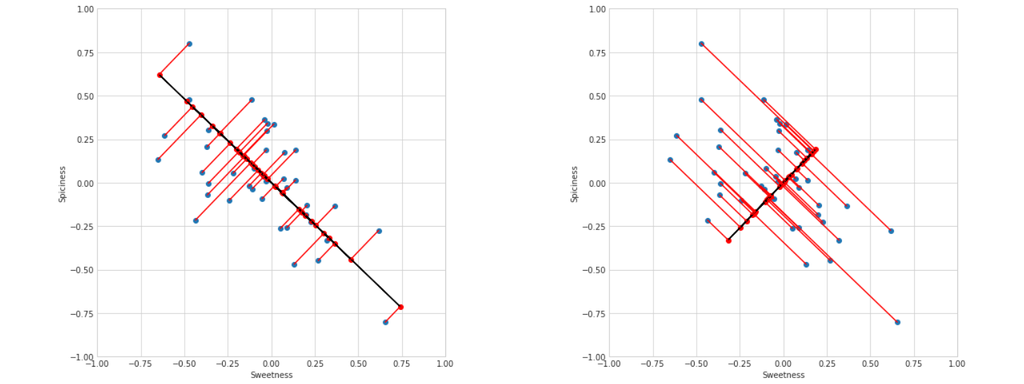

- A la **derecha** se observa la segunda componente principal. Es perpendicular a la primera componente principal y recoge la máxima varianza posible que no ha podido ser recogida en la primera.

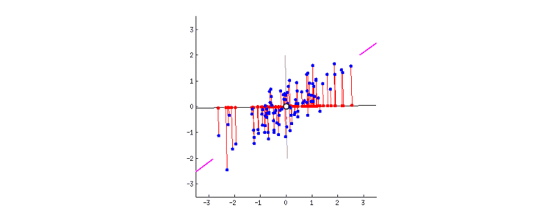

- **IMPORTANTE** La condición de ortoganalidad equivale a decir que la segunda componente principal no está correlacionada con la primera, es decir, entre ambas no hay repetición o redundancia en la información, al contrario de lo que sucede con las variables originales.

# PCA y reducción de la dimensionalidad

- En general, si hubiera $p$ variables originales, obtenemos $p$ componentes principales, todas ellas ortogonales entre sí. Es evidente que la primera componente es mucho mejor capturando la información de los datos que la segunda. Y la segunda explicaría más varianza que la tercera (si hubiera más variables) y así sucesivamente.
- Con independencia de la dimensionalidad del dataset original, las componentes principales se obtienen y se ordenan de acuedo a la cantidad de varianza que pueden capturar de los datos.
- A continuación, vamos a ver cómo se obtienen las componentes principales a partir de un conjunto de datos $\mathbf{X}_{n\times p}=(\mathbf{X}_1,\mathbf{X}_2,...,\mathbf{X}_p)$, donde cada $\mathbf{X}_i$ es una variable, $i=1,..,p$.
- **OBSERVACIÓN**: Vamos a suponer que las variables está centradas en la media, es decir, $\bar{\mathbf{X}_i}=0$. En general, los métodos para calcular las CPs aplican un centrado de los datos
  $$\mathbf{X} \rightarrow \mathbf{X}-\mathbf{1}\bar{\mathbf{X}}^t$$
  donde $1_{n\times 1}=\left(\begin{array}{c} 1\\ . \\ . \\ 1\end{array}\right)$ y $\bar{\mathbf{X}}^t_{1\times p}=(\bar{\mathbf{X}}_{1},..,\bar{\mathbf{X}}_{p})$.

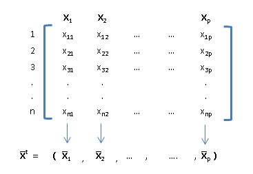

# Cálculo de las CPs: la primera componente principal

- La **primera componente principal** se puede expresar como $Y_1=\left(\begin{array}{c}Y_{11}\\ . \\ . \\ Y_{n1}\end{array}\right)$, y consiste en una combinación lineal de las variables de $X$
  $$Y_1=\mathbf{X}\mathbf{\gamma_1} ,$$
  donde
  $$\gamma_1=\left(\begin{array}{c}\gamma_{11}\\ . \\ . \\ \gamma_{p1}\end{array}\right)$$
  es el vector de proyección.
- Por tanto, observar que $Y_1=\gamma_{11}\mathbf{X_1} + ... +\gamma_{p1}\mathbf{X_p}$. Hay que decir que se trata de una combinación lineal normalizada (o sea, $\mathbf{\gamma_1}^t \mathbf{\gamma_1}=\sum_{j=1}^p \gamma^{2}_{j1}= 1$).
- En definitiva, para calcular la primera componente principal se require resolver el siguiente problema
  $$\begin{equation}
  \begin{aligned}
  & \underset{\mathbf{\gamma_1}}{\text{maximize}}
  & & \mathbf{\gamma_1}^t (X^tX) \mathbf{\gamma_1} \\
  & \text{subject to}
  & & \mathbf{\gamma_1}^t \mathbf{\gamma_1} = 1
  \end{aligned}
  \end{equation}$$

# Cálculo de las CPs: la primera componente principal

- Hay 2 preguntas importantes:
  - ¿quién es $\gamma_1^t=(\gamma_{11},..,\gamma_{p1})$?
  - ¿por qué hay que maximizar $\mathbf{\gamma_1}^t (X^tX) \mathbf{\gamma_1}$?
- Observar que $X^tX = (n-1)\Sigma$, es decir, $\Sigma$ la matriz de varianzas-covarianzas de $X$.
  $$\Sigma=\left(\begin{array}{cccc}\sigma^2_1 & \sigma_{12} & \dots &\sigma_{1p}\\ \sigma_{21} & \sigma^2_2 & \dots &\sigma_{2p}\\ \vdots & \vdots & \ddots & \vdots \\ \sigma_{p1} & \sigma_{p2} & \dots & \sigma^2_p\end{array}\right)$$
- Entonces
  $$\begin{equation}
  \begin{aligned}
  & \underset{\mathbf{\gamma_1}}{\text{maximize}}
  & & \mathbf{\gamma_1}^t \Sigma \mathbf{\gamma_1} \\
  & \text{subject to}
  & & \mathbf{\gamma_1}^t \mathbf{\gamma_1} = 1
  \end{aligned}
  \end{equation}$$
- Si la **primera CP** es $Y_1=\mathbf{X}\mathbf{\gamma_1}$, entonces $Var(Y_1)=\mathbf{\gamma_1}^t \Sigma \mathbf{\gamma_1}=\lambda_1$, con lo cual el problema anterior equivale a maximizar $\lambda_1$ tal que
  $$\Sigma \mathbf{\gamma_1}=\lambda_1 \mathbf{\gamma_1}$$
- La solución a este problema se obtiene cuando $Var(Y_1)=\lambda_1$ corresponde al mayor autovalor de $\Sigma$, con $\gamma_1$ el autovector correspondiente a dicho autovalor.

# Cálculo de las CPs: la segunda componente principal

- De forma similar, para obtener la **segunda CP** hay que resolver
  $$\begin{equation}
  \begin{aligned}
  & \underset{\mathbf{\gamma_1}}{\text{maximize}}
  & & \mathbf{\gamma_2}^t \Sigma \mathbf{\gamma_2} \\
  & \text{subject to}
  & & \mathbf{\gamma_1}^t \mathbf{\gamma_1} = 0 \\
  & & & \mathbf{\gamma_2}^t \mathbf{\gamma_2} = 1
  \end{aligned}
  \end{equation}$$

con lo cual, $Y_2=\mathbf{X}\mathbf{\gamma_2}$, donde $Var(Y_2)=\lambda_2$ es el segundo mayor autovalor de $\Sigma$ y $\gamma_2$ el autovector asociado.

- En general, las **componentes principales** son
  $$\begin{array}{lll} Y_1 & =\mathbf{X}\mathbf{\gamma_1} & = \gamma_{11}X_1 + \gamma_{21}X_2 + \dots + \gamma_{p1}X_p \\
  Y_2 & =\mathbf{X}\mathbf{\gamma_2} & = \gamma_{12}X_1 + \gamma_{22}X_2 + \dots + \gamma_{p2}X_p \\ & & \vdots \\ Y_p & =\mathbf{X}\mathbf{\gamma_p} & = \gamma_{1p}X_1 + \gamma_{2p}X_2 + \dots +\gamma_{pp}X_p\end{array}$$

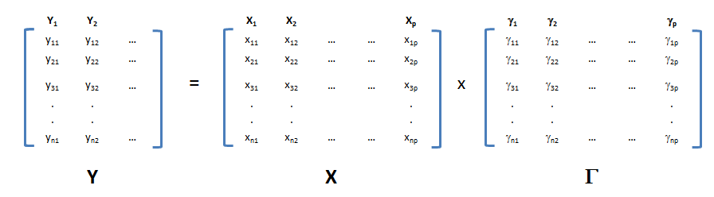